# INRIA : phone detection

There are the steps that I use for solve a IA problem:

#### 1) Problem Definition:

Clearly define the problem and understand the type of data you're working with (e.g., images, text, numbers).

#### 2) Data Preprocessing:

Clean and format the data.

#### 3) Model Selection:

Choose a suitable model architecture based on the nature of your problem

#### 4) Data Splitting:

Split your dataset into training and testing sets to evaluate how well your model generalizes to new, unseen data.

#### 5) Training:

Feed the training data into the model and optimize its parameters

#### 6) Evaluation:

Assess your model's performance on the testing set using appropriate metrics (e.g., accuracy, precision, recall).

#### 7) Adjustment and Optimization:

Fine-tune your model based on evaluation results. Experiment with hyperparameters to improve performance.

#### 8) Final Testing:

Evaluate your optimized model on a separate test set to ensure it generalizes well to completely new data.

#### 9) Deployment (if applicable):

If your model is ready for real-world use, integrate it into the intended system or application.

#### 10) Monitoring and Maintenance (if applicable):

Continuously monitor your model's performance. Update the model if new data becomes available or if performance deteriorates over time.

# 1) Problem Definition:

The objective of this task is to identify the coordinates of a phone within an image. To achieve this, an object detection algorithm is employed.

```python
# Standard Python libraries and general operations
import os
import shutil
from pathlib import Path
from dataclasses import dataclass
from IPython.display import display

# Libraries for data manipulation and image processing
from PIL import Image
import numpy as np
import cv2

# PyTorch libraries for deep learning
from torch.utils.data import Dataset

# torchvision libraries for computer vision models
from torchvision import transforms

# Specific library from Ultralytics (YOLO)
from ultralytics import YOLO
```

# 2) Data Preprocessing

For this purpose, I prefer utilizing the tutorial link to create a custom dataset: https://pytorch.org/tutorials/beginner/data_loading_tutorial.html. Consequently, I design some transformations and the main class

for the Data Augmentation I used

- **RandomVerticalFlip** : This augmentation randomly flips the image vertically (upside-down) with a certain probability (p).
- **RandomHorizontalFlip** : Similar to the vertical flip, this augmentation randomly flips the image horizontally (left to right) with a certain probability (p).
- **RandomTranslate** : This augmentation randomly translates (shifts) the image and adjusts bounding box coordinates with a certain probability (p).

```python
#labels path

path = "find_phone_data/labels.txt"
```

```python
def imshow(img):
    """
    Display an image in the IPython environment using OpenCV and IPython.display.

    Args:
        img (numpy array): Input image.

    Returns:
        None
    """
    import cv2
    import IPython

    # Encode the image as a JPEG for display in IPython
    _, ret = cv2.imencode('.jpg', img)

    # Create an IPython display Image object
    i = IPython.display.Image(data=ret)

    # Display the image
    IPython.display.display(i)
```

```python
class Resize(object):

        """Rescale the image in a sample to a given size.

    Args:
        output_size (tuple): Desired output size. If tuple, output is
            matched to output_size.
    """

        def __init__(self ,size):
            self.size = size

        def __call__(self, sample):

            # Resizes the image in the 'sample' dictionary to the specified size using OpenCV's cv2.resize function
            sample["image"] = cv2.resize(sample["image"], self.size)

            return sample
```

```python
class RandomHorizontalFlip(object):


        """Apply random horizontal flip to the image and adjust bounding box coordinates in a sample.

    Args:
        p (float): Probability of applying the horizontal flip.

    """

        def __init__(self ,p):
            self.p = p

        def __call__(self, sample):

            if np.random.rand() < self.p:

                # Flip the image horizontally

                sample["image"] = cv2.flip(sample["image"],1)

                 # Adjust bounding box coordinates

                sample["x"] = 1 - sample["x"]

            return sample
```

```python
class RandomVerticalFlip(object):

        """

    Apply random vertical flip to the image and adjust bounding box coordinates in a sample.

    Args:
        p (float): Probability of applying the vertical flip.

    """

        def __init__(self ,p):
            self.p = p

        def __call__(self, sample):

            if np.random.rand() < self.p:

                # Flip the image vertically

                sample["image"] = cv2.flip(sample["image"],0)

                # Adjust bounding box coordinates

                sample["y"] = 1 - sample["y"]

            return sample
```

```python
class RandomTranslate(object):
    """
    Randomly translate the image and adjust bounding box coordinates in a sample.

    Args:
        p (float): Probability of applying the translation.
    """

    def __init__(self, p):
        self.p = p

    def __call__(self, sample):
        if np.random.rand() < self.p:

            max_translation = 0.2

            # Generate random translations in x and y
            translation_x = np.random.uniform(-max_translation, max_translation)

            translation_y = np.random.uniform(-max_translation, max_translation)

            # Create a translation transformation matrix
            translation_matrix = np.array([[1, 0, translation_x * sample["image"].shape[1]],
                                           [0, 1, translation_y * sample["image"].shape[0]]], dtype=np.float32)

            # Apply translation to the image using OpenCV's warpAffine function
            sample["image"] = cv2.warpAffine(sample["image"], translation_matrix, (sample["image"].shape[1], sample["image"].shape[0]))

            # Adjust bounding box coordinates based on the translation
            sample["x"] += translation_x
            sample["y"] += translation_y

        return sample
```

```python
class Create_BBox(object):

        """Create a bounding box.

    Args:
        mean (int): Mean of a normal distribution for the height and width of the box.
        std (int): Standard deviation of a normal distribution for the height and width of the box.
    """

        def __init__(self ,mean,std):

            self.mean = mean
            self.std = std

        def __call__(self, sample):

            # Extract the image from the sample dictionary

            image = sample["image"]

            # Generate random bounding box dimensions based on a normal distribution

            h = np.random.normal(self.mean, self.std)/image.shape[1]
            w = np.random.normal(self.mean, self.std)/image.shape[0]

            # Add the generated dimensions to the sample dictionary

            sample['h'] = h
            sample['w'] = w

            return sample
```

```python
class PhoneImagesDataset(Dataset):
    """Phone Images dataset"""

    def __init__(self, image_paths, transform=None):

        """
        Arguments:
            image_paths (string): labels.txt path
        """

        self.image_paths = image_paths

        self.transform = transform

        self.idx = 0

    def __iter__(self):

        """Returns the iterator object."""

        return self

    def __next__(self):

        """
        Retrieves the next item in the dataset.
        """

        self.idx += 1

        try:

            return self[self.idx-1]

        except IndexError:

            self.idx = 0

            raise StopIteration

    def __len__(self):
        return len(self.image_paths)

    def __getitem__(self, idx):

        """
        Retrieves a sample from the dataset.

        Args:
            idx (int): Index of the sample.

        Returns:
            dict: A dictionary containing image and label information.
        """

        data = np.genfromtxt(self.image_paths, delimiter=' ', dtype=None, encoding=None)
        image_filepath = "find_phone_data/" + data[idx][0]

        # Read the image using OpenCV

        image = cv2.imread(image_filepath)

        # Extract coordinates from the data

        x =  data[idx][1]
        y =  data[idx][2]

        # Create a sample dictionary with image and coordinate information

        sample = {"name": data[idx][0], "image": image, "x": x , "y" : y , "h": 0 , "w" : 0}

        # Apply the transform if provided
        if self.transform:
            sample = self.transform(sample)

        return sample
```

For the chosen parameters:

- Image size: 256x256
- Mean for bounding box dimensions: 40
- Standard deviation for bounding box dimensions: 3
- Probability: 0.5

```python
#Create the dataset

dataset = PhoneImagesDataset(path,transform= transforms.Compose([Resize((256,256)),RandomHorizontalFlip(0.5),RandomVerticalFlip(0.5),RandomTranslate(0.5),Create_BBox(40,3)]))
```

This dictionary contains information about a sample from the dataset:

```python
#Example
dataset[80]
```

```
{'name': '62.jpg',
 'image': array([[[139, 154, 163],
         [145, 160, 169],
         [144, 159, 168],
         ...,
         [122, 140, 151],
         [127, 145, 156],
         [134, 153, 161]],

        [[135, 150, 158],
         [145, 160, 168],
         [145, 160, 169],
         ...,
         [121, 139, 150],
         [124, 142, 153],
         [130, 149, 157]],

        [[130, 146, 153],
         [137, 153, 160],
         [145, 160, 169],
         ...,
         [120, 138, 149],
         [120, 138, 149],
         [126, 145, 153]],

        ...,

        [[ 91, 101, 111],
         [ 78,  89,  97],
         [ 65,  74,  83],
         ...,
         [ 80,  90, 100],
         [ 76,  87,  95],
         [ 88,  99, 107]],

        [[ 82,  93, 102],
         [ 84,  95, 103],
         [ 67,  77,  85],
         ...,
         [ 81,  91, 101],
         [ 84,  95, 103],
         [ 86,  97, 105]],

        [[ 83,  94, 102],
         [ 89, 100, 108],
         [ 62,  73,  81],
         ...,
         [ 74,  84,  94],
         [ 91, 102, 110],
         [ 83,  94, 102]]], dtype=uint8),
 'x': 0.8469,
 'y': 0.7545999999999999,
 'h': 0.17407808065677022,
 'w': 0.1700324334378971}
```

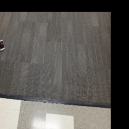

```python
# Show an image and a point

# Access a sample from the dataset
sample = dataset[80]

# Retrieve the image, x-coordinate, and y-coordinate from the sample
img = sample["image"]
x = sample["x"]
y = sample["y"]

# Define a red color for the point
red = [0, 0, 255]

# Draw a red point on the image at the specified (x, y) coordinate
img = cv2.circle(img, (int(x * img.shape[1]), int(y * img.shape[0])), 2, red, -1)

# Display the image using cv2.imshow
cv2.imshow('img', img)

# Display the image using a custom 'imshow' function
imshow(img)
```

```python
#Example
dataset[70]
```

```
{'name': '67.jpg',
 'image': array([[[  0,   0,   0],
         [  0,   0,   0],
         [  0,   0,   0],
         ...,
         [156, 159, 164],
         [158, 160, 164],
         [158, 160, 164]],

        [[  0,   0,   0],
         [  0,   0,   0],
         [  0,   0,   0],
         ...,
         [155, 158, 163],
         [157, 159, 163],
         [160, 161, 165]],

        [[  0,   0,   0],
         [  0,   0,   0],
         [  0,   0,   0],
         ...,
         [161, 163, 168],
         [161, 162, 167],
         [162, 163, 167]],

        ...,

        [[  0,   0,   0],
         [  0,   0,   0],
         [  0,   0,   0],
         ...,
         [  0,   0,   0],
         [  0,   0,   0],
         [  0,   0,   0]],

        [[  0,   0,   0],
         [  0,   0,   0],
         [  0,   0,   0],
         ...,
         [  0,   0,   0],
         [  0,   0,   0],
         [  0,   0,   0]],

        [[  0,   0,   0],
         [  0,   0,   0],
         [  0,   0,   0],
         ...,
         [  0,   0,   0],
         [  0,   0,   0],
         [  0,   0,   0]]], dtype=uint8),
 'x': 0.14416663177829714,
 'y': 0.0009835961084909695,
 'h': 0.15259972816749967,
 'w': 0.15046147226663678}
```

# 3) Model Selection

In this part, I thought a lot of options:

- Vision Transformers for Object Detection (ViT)
- U-net https://arxiv.org/abs/1806.07564
- Faster R-CNN https://arxiv.org/abs/1506.01497
- YOLO: You Only Look Once
- A classic CNN, or Convolutional Neural Network

I opted to leverage a pre-trained model due to a limited dataset, and my familiarity with YOLO led me to choose it for its proven effectiveness. Given my past positive experiences with YOLO, I decided to employ this model, which excels in various tasks. Consequently, I had to generate random bounding boxes for my specific use case.

So for that I used this tutorial https://docs.ultralytics.com/fr/yolov5/tutorials/train_custom_data/#22-create-labels.

# 4) Data Splitting

For implementing data splitting in the YOLO algorithm, adhere to the following folder distribution:

- Dataset
  - Images
    - Train
      - Image1.jpg
      - Image2.jpg
      - ...
    - Validation
      - Image1.jpg
      - Image2.jpg
      - ...
    - Test
      - Image1.jpg
      - Image2.jpg
      - ...
  - Labels
    - Train
      - Label1.txt
      - Label2.txt
      - ...
    - Validation
      - Label1.txt
      - Label2.txt
      - ...
    - Test
      - Label1.txt
      - Label2.txt
      - ...

```python
# Define the root folder for the dataset
root_folder = Path("./datasets")

# Define subfolders for images and labels
images_folder = root_folder / "images"
labels_folder = root_folder / "labels"

# Define subfolders for training, validation, and testing sets
img_train_path = images_folder / "train"
img_val_path = images_folder / "val"
img_test_path = images_folder / "test"
labels_train_path = labels_folder / "train"
labels_val_path = labels_folder / "val"
labels_test_path = labels_folder / "test"

# Create the necessary directory structure
img_train_path.mkdir(parents=True, exist_ok=True)
img_test_path.mkdir(parents=True, exist_ok=True)
img_val_path.mkdir(parents=True, exist_ok=True)
labels_train_path.mkdir(parents=True, exist_ok=True)
labels_test_path.mkdir(parents=True, exist_ok=True)
labels_val_path.mkdir(parents=True, exist_ok=True)
```

```python
# Initialize a counter variable
i = 0

# Iterate through the dataset
for image in dataset:
    # Check if the current image should be part of the validation set (first 8 images)
    if i < 8:
        # Extract image information
        name = image['name']

        label_path = labels_val_path / f"{name.split('.')[0]}.txt"

        # Create a YOLO format label string
        label_str = f"0 {image['x']} {image['y']} {image['w']} {image['h']}"

        # Write the label string to a label file
        with open(label_path, 'w') as file:
            file.write(label_str)

        output_path = os.path.join(img_val_path, name)

        # Copy the image to the validation images folder
        cv2.imwrite(output_path, image["image"])
    else:
        # For images beyond the first 8, add them to the training set
        name = image['name']
        label_path = labels_train_path / f"{name.split('.')[0]}.txt"

        # Create a YOLO format label string
        label_str = f"0 {image['x']} {image['y']} {image['w']} {image['h']}"

        # Write the label string to a label file
        with open(label_path, 'w') as file:
            file.write(label_str)

        output_path = os.path.join(img_train_path, name)

        # Copy the image to the training images folder
        cv2.imwrite(output_path, image["image"])

    # Increment the counter
    i = i + 1
```

```python
#YOLO model
model = YOLO('yolov8n.pt')
```

# 5) Training

The training configuration includes 15 epochs, an image size of 256, and the CPU as the device. These settings are adjustable based on specific requirements.

```python
summary = model.train(data='dataset.yaml', epochs=15, imgsz=256, device='cpu')
```

[output not shown]

```
[W NNPACK.cpp:64] Could not initialize NNPACK! Reason: Unsupported hardware.
```

```
Transferred 319/355 items from pretrained weights
Freezing layer 'model.22.dfl.conv.weight'
```

```
train: Scanning /Users/sofia/Documents/INRIA/datasets/labels/train... 121 images
```

[output not shown]

```
val: Scanning /Users/sofia/Documents/INRIA/datasets/labels/train.cache... 121 im
```

[output not shown]

```
Plotting labels to runs/detect/train12/labels.jpg...
optimizer: 'optimizer=auto' found, ignoring 'lr0=0.01' and 'momentum=0.937' and determining best 'optimizer', 'lr0' and 'momentum' automatically...
optimizer: AdamW(lr=0.002, momentum=0.9) with parameter groups 57 weight(decay=0.0), 64 weight(decay=0.0005), 63 bias(decay=0.0)
Image sizes 256 train, 256 val
Using 0 dataloader workers
Logging results to runs/detect/train12
Starting training for 15 epochs...

      Epoch    GPU_mem   box_loss   cls_loss   dfl_loss  Instances       Size
```

```
       1/15         0G       2.71      3.703      1.557         12        256: 1
                 Class     Images  Instances      Box(P          R      mAP50  m
```

```
                   all        118        118    0.00544      0.941      0.137     0.0553
```

```
      Epoch    GPU_mem   box_loss   cls_loss   dfl_loss  Instances       Size
```

```
       2/15         0G       2.03      2.405      1.246         11        256: 1
                 Class     Images  Instances      Box(P          R      mAP50  m
```

```
                   all        118        118    0.00594          1      0.539      0.142
```

```
      Epoch    GPU_mem   box_loss   cls_loss   dfl_loss  Instances       Size
```

```
       3/15         0G      1.679      1.489       1.13         13        256: 1
                 Class     Images  Instances      Box(P          R      mAP50  m
```

```
                   all        118        118    0.00621          1      0.313     0.0611
```

```
      Epoch    GPU_mem   box_loss   cls_loss   dfl_loss  Instances       Size
```

```
       4/15         0G       1.54      1.417      1.089          9        256: 1
                 Class     Images  Instances      Box(P          R      mAP50  m
```

```
                   all        118        118    0.00653          1      0.177     0.0446
```

```
      Epoch    GPU_mem   box_loss   cls_loss   dfl_loss  Instances       Size
```

```
       5/15         0G      1.571      1.369      1.111          9        256: 1
                 Class     Images  Instances      Box(P          R      mAP50  m
```

```
                   all        118        118    0.00649          1      0.214     0.0935
```

```
Closing dataloader mosaic

      Epoch    GPU_mem   box_loss   cls_loss   dfl_loss  Instances       Size
```

```
       6/15         0G      1.548      1.496      1.111          6        256: 1
                 Class     Images  Instances      Box(P          R      mAP50  m
```

```
                   all        118        118     0.0267          1      0.863      0.368
```

```
      Epoch    GPU_mem   box_loss   cls_loss   dfl_loss  Instances       Size
```

```
       7/15         0G      1.523      1.344      1.113          6        256: 1
                 Class     Images  Instances      Box(P          R      mAP50  m
```

```
                   all        118        118    0.00652          1      0.918      0.479
```

```
      Epoch    GPU_mem   box_loss   cls_loss   dfl_loss  Instances       Size
```

```
       8/15         0G        1.4      1.336      1.119          6        256: 1
                 Class     Images  Instances      Box(P          R      mAP50  m
```

```
                   all        118        118    0.00674          1      0.769      0.405
```

```
      Epoch    GPU_mem   box_loss   cls_loss   dfl_loss  Instances       Size
```

```
       9/15         0G      1.387      1.275      1.101          5        256: 1
                 Class     Images  Instances      Box(P          R      mAP50  m
```

```
                   all        118        118    0.00697          1      0.874      0.505
```

```
      Epoch    GPU_mem   box_loss   cls_loss   dfl_loss  Instances       Size
```

```
      10/15         0G      1.292      1.141       1.07          6        256: 1
                 Class     Images  Instances      Box(P          R      mAP50  m
```

```
                   all        118        118          1      0.332      0.927      0.524
```

```
      Epoch    GPU_mem   box_loss   cls_loss   dfl_loss  Instances       Size
```

```
      11/15         0G      1.318      1.157      1.121          5        256: 1
                 Class     Images  Instances      Box(P          R      mAP50  m
```

```
                   all        118        118          1      0.603      0.968      0.605
```

```
      Epoch    GPU_mem   box_loss   cls_loss   dfl_loss  Instances       Size
```

```
      12/15         0G      1.272       1.11      1.105          6        256: 1
                 Class     Images  Instances      Box(P          R      mAP50  m
```

```
                   all        118        118          1      0.765      0.988      0.615
```

```
      Epoch    GPU_mem   box_loss   cls_loss   dfl_loss  Instances       Size
```

```
      13/15         0G       1.25      1.013      1.056          6        256: 1
                 Class     Images  Instances      Box(P          R      mAP50  m
```

```
                   all        118        118      0.991      0.946       0.99      0.664
```

```
      Epoch    GPU_mem   box_loss   cls_loss   dfl_loss  Instances       Size
```

```
      14/15         0G      1.255     0.9734      1.095          6        256: 1
                 Class     Images  Instances      Box(P          R      mAP50  m
```

```
                   all        118        118      0.985      0.966      0.993      0.573
```

```
      Epoch    GPU_mem   box_loss   cls_loss   dfl_loss  Instances       Size
```

```
      15/15         0G      1.293     0.9778      1.114          6        256: 1
                 Class     Images  Instances      Box(P          R      mAP50  m
```

```
                   all        118        118      0.991      0.961      0.993      0.626
```

```
15 epochs completed in 0.086 hours.
Optimizer stripped from runs/detect/train12/weights/last.pt, 6.2MB
Optimizer stripped from runs/detect/train12/weights/best.pt, 6.2MB

Validating runs/detect/train12/weights/best.pt...
Ultralytics YOLOv8.1.9 🚀 Python-3.11.3 torch-2.0.1 CPU (Apple M2)
Model summary (fused): 168 layers, 3005843 parameters, 0 gradients, 8.1 GFLOPs
```

```
                 Class     Images  Instances      Box(P          R      mAP50  m
```

```
                   all        118        118      0.991       0.94       0.99      0.662
Speed: 0.2ms preprocess, 42.2ms inference, 0.0ms loss, 0.3ms postprocess per image
Results saved to runs/detect/train12
```

```python
#save the model
model.save('best_find_phone.pt')
```